# NAVDAT receiver

Developed by Konovalov Vitaly (vskonovalov@inbox.ru) for Central Scientific Research Institute "Kurs", 2020 г.

This document describes the developed model of the NAVDAT receiver. Recommendation ITU-R M.2010 (01/2019) [1] was used as the main description of the protocol.

## Transmitter model

In this document, the simplified model of the transmitter is used. It does not implement MIS, TIS and DS streams and all the data cells are modulated with the same modulation. Also, to compare the model performance for different carrier occupancy modes, the frames for each mode is generated.

To prettify the pictures, the transmitter generates two sequential frames.

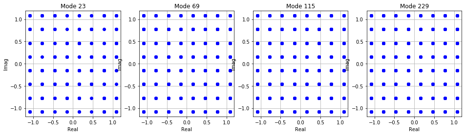

## Channel

According to the information from [[1, table 5, p.7](https://www.itu.int/dms_pub/itu-r/opb/rep/R-REP-M.2443-2019-PDF-E.pdf)] and [[3](https://www.itu.int/dms_pubrec/itu-r/rec/p/R-REC-P.1321-5-201507-I!!PDF-E.pdf)] there is two ways of signal propagation which should be considered: *ground wave propagation* (for day time) and *sky-wave propagation* (for night time). For *ground wave propagation* simple AWGN channel could be used and for *sky-wave propagation* we will use tap-model for 700 kHz carrier described in [[3, clause 3, p.2](https://www.itu.int/dms_pubrec/itu-r/rec/p/R-REC-P.1321-5-201507-I!!PDF-E.pdf)]. However, this model does not fully meet the requirements of [[1, table 4, p.6](https://www.itu.int/dms_pub/itu-r/opb/rep/R-REP-M.2443-2019-PDF-E.pdf)], because it does not implement time selectiveness.

The plots of amplitude attenuation for the three different distances (100 km, 200 km and 500 km) are given below.

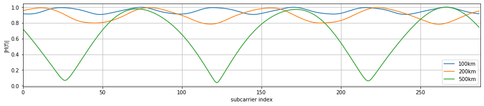

### AWGN

To prettify the plots the integer sample delay is added to the beginning of the transmission and then the AWGN noise is applied. The transmitted signal is shown below:

```
Add 679 delay cycles
23 RX Signal power: 0.0869. Noise power: 0.0005
69 RX Signal power: 0.2300. Noise power: 0.0015
115 RX Signal power: 0.3707. Noise power: 0.0023
229 RX Signal power: 0.7667. Noise power: 0.0048
```

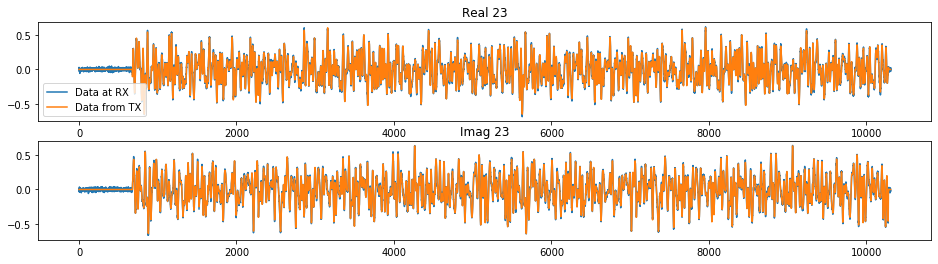

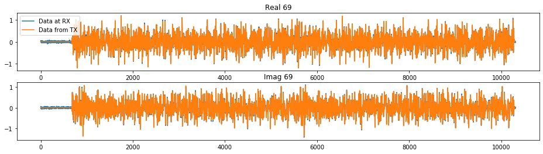

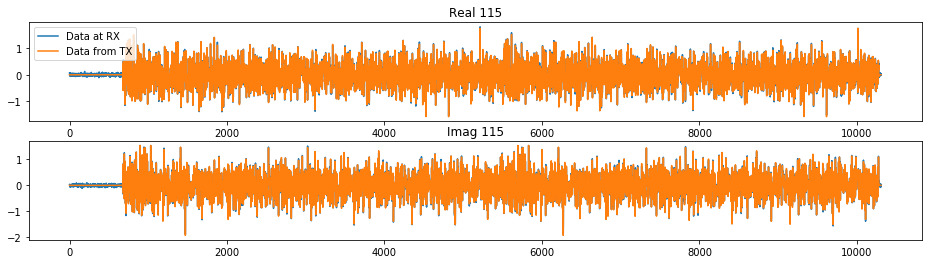

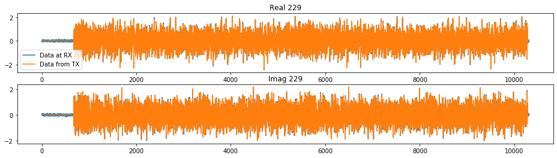

## Receiver front-end distortions

Receiver front-end distortions mostly depend on the difference between clock source in a transmitter and a receiver.

### Carier Frequency Offset

If both receiver and transmitter use digital mixers, CFO could be derived from clock source accuracy. Here CFO frequency is calculated from accuracy value in ppm and 1 ppm => 1 Hz CFO.

```
CFO = 50.0 Hz
```

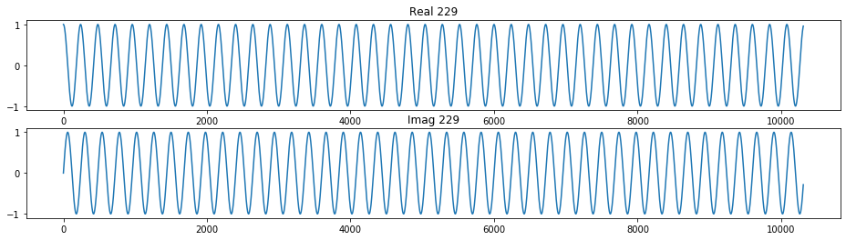

### Sampling Rate Offset

SRO also depends on the difference between sample rates in the receiver and transmitter. In most cases, SRO is not large and does not affect the performance of the algorithms. This model does not implement SRO distortion.

# Receiver model

The receiver model described in this document consists of frame acquisition, coarse & fine STO estimation, CFO estimation & compensation (limited by ±104 Hz) and channel estimation & compensation.

## Symbol timing offset estimation

### Coarse symbol timing offset and frame acquisition

For frame acquisition and coarse STO estimation, the algorithm of GI autocorrelation is used. The power of the received signal depends on the frame frequency occupancy mode, because of the different number of subcarriers used. To handle this the resulting metric normalize squared amplitude of autocorrelation by the squared moving average of signal power (GI size). If this metric exceeds a threshold the symbol is acquired and the following number of samples, equal to the frame length, are ignored.

To avoid early detection due to noise in the channel the algorithm also applies power window.

The fractional CFO estimation is joint with coarse STO estimation and could estimate CFO in the range ±20.83 Hz. However, to better estimate CFO we need to calculate fine STO first.

```
Real delay: 679 samples

Mode 23
```

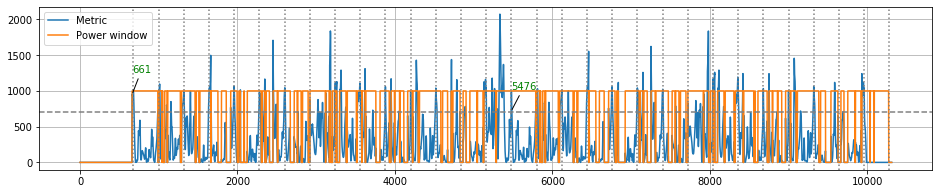

```
Mode 69
```

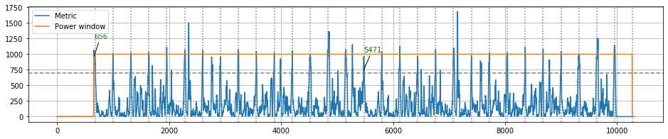

```
Mode 115
```

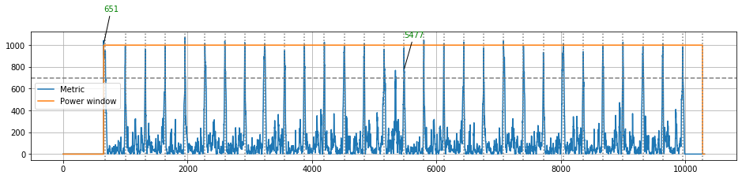

```
Mode 229
```

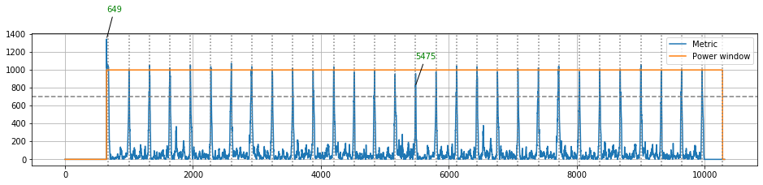

### Fine symbol timing offset estimation

To estimate fine STO the algorithm of cross-correlation with known header is applied. Due to the nested header structure, only one header (header for 229 subcarriers) can be used to detect frames in different carrier occupancy modes.

This algorithm is also used to detect the integer part of CFO. Instead of only 1 correlator, we use several, each with different CFO shift applied (-83.33, -41.67, 0, 41.67 и 83.33 Hz). With the fractional CFO estimation algorithm, this method can estimate CFO in range ±104 Hz. More correlations could be added if a wider CFO range is necessary.

```
Delay + GI = 679 + 32 = 711
Mode 23
```

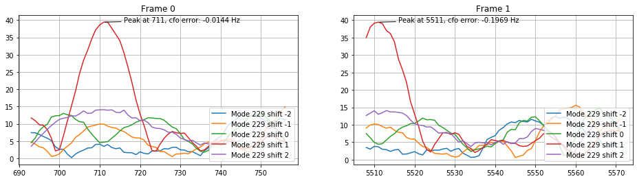

```
Mode 69
```

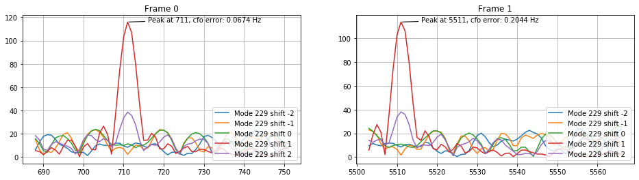

```
Mode 115
```

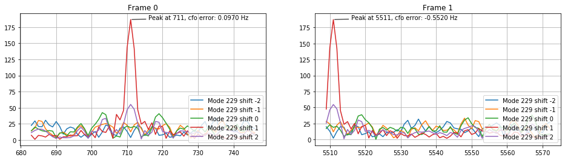

```
Mode 229
```

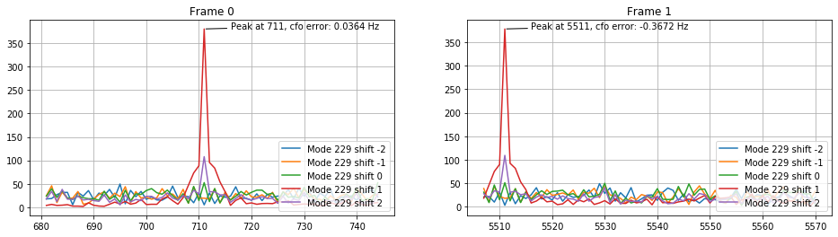

## Translation to the frequency domain

After fine STO the frames could be extracted from samples and translated to the frequency domain. The FFT algorithm is used here. To compensate IFFT scaling the samples are divided by the square root of *N* (FFT size).

## Channel estimation and compenstion

In this model algorithm of channel estimation by scattered pilots is used. Algorithm estimates pilot distortions and interpolate them firstly in time direction and then in frequnecy direction. It also compensates small residual CFO.

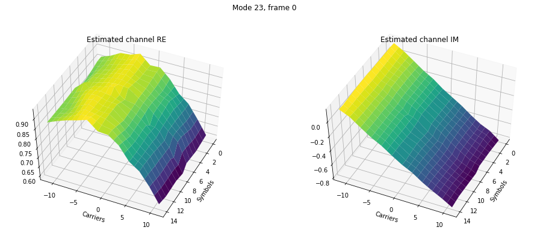

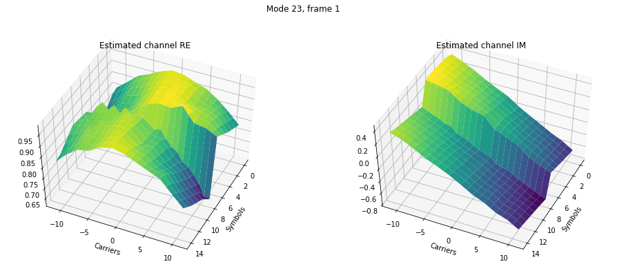

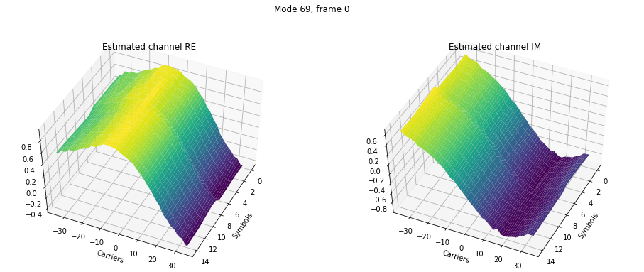

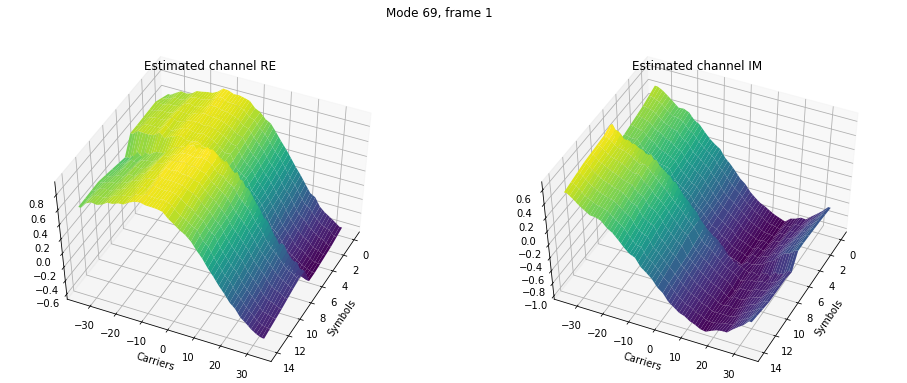

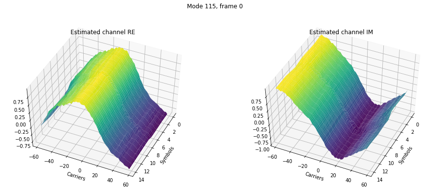

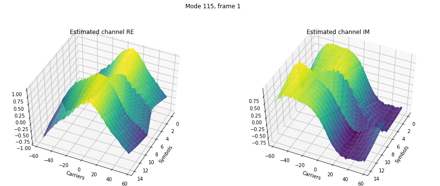

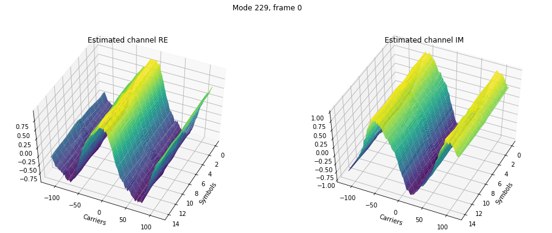

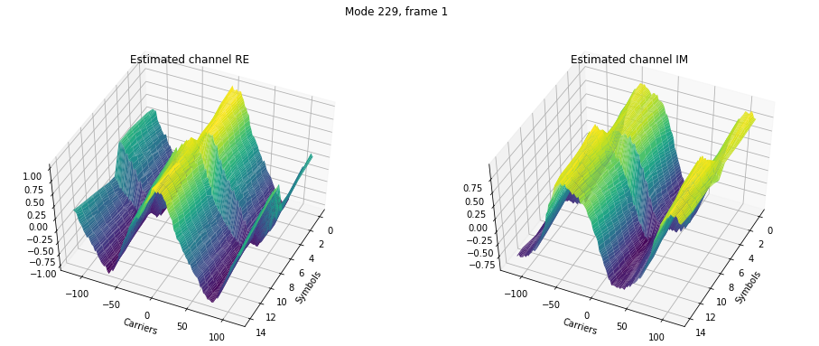

## Received frames constellation diagrams

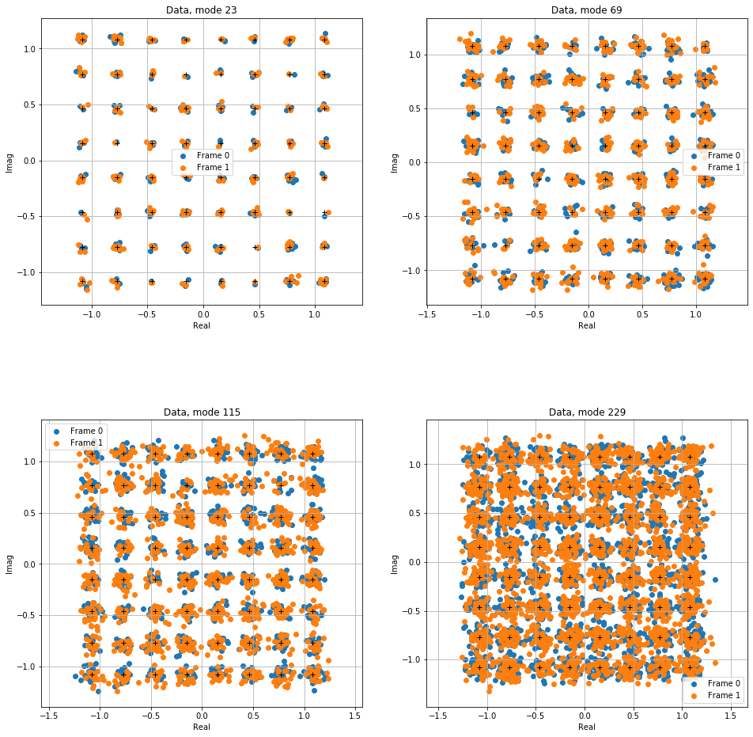

## Used links and resources

1. [Report ITU-R M.2443-0 (11/2018), clauses 6 & 6.1, p. 6](https://www.itu.int/dms_pub/itu-r/opb/rep/R-REP-M.2443-2019-PDF-E.pdf)
2. [Reccomendation ITU-R BS.1615, clause 3, p. 13](https://www.itu.int/dms_pubrec/itu-r/rec/bs/R-REC-BS.1615-0-200306-S!!PDF-E.pdf)
3. [Recommendation ITU-R P.1321-5(07/2015)](https://www.itu.int/dms_pubrec/itu-r/rec/p/R-REC-P.1321-5-201507-I!!PDF-E.pdf)
4. [Recommendation ITU-R P.1407-7](https://www.itu.int/dms_pubrec/itu-r/rec/p/R-REC-P.1407-7-201908-I!!PDF-E.pdf)
5. [Wireless Channel Models for Maritime Communications, Jue Wang, 9 November 2018](https://ieeexplore.ieee.org/stamp/stamp.jsp?tp=&arnumber=8528349)
6. OFDM Baseband Receiver Design for Wireless Communications, Tzi-Dar Chiueh, Pei-Yun Tsai, 2007